# Strategy and Tactics of Distributive Bargaining

Session 1

Luis F. Gómez L.

luis.gomezl@unimilitar.edu.co

Distance Learning Faculty

8 September, 2026

# Please Read Me

- Check the message **Welcome greeting** published in the News Bulletin Board.
- Dear student please edit your profile uploading a photo where your face is clearly visible.
- The purpose of the virtual meetings is to answer questions and not to make a summary of the study material.
- This presentation is based on (Lewicki et al., 2024, Chapter 2)
- **Purpose**
  - Understand the core elements of distributive negotiation scenarios, along with the specific strategies and tactics applied in this context.

# Elements of a distributive negotiation situation

- Buyer: Jackson ($J$) and Seller: Sofia ($S$)[^1]
  - Resistance point $J$, $Rp_J$: 150K USD
  - Resistance point $S$, $Rp_S$: 130K USD

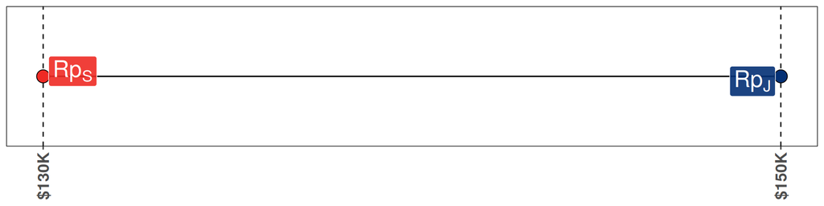

Figure 1: Resistance points

- Buyer: Jackson ($J$) and Seller: Sofia ($S$)
  - Initial offer $J$, $Io_J$: 133K USD
  - Initial offer $S$, $Io_S$: 145K USD

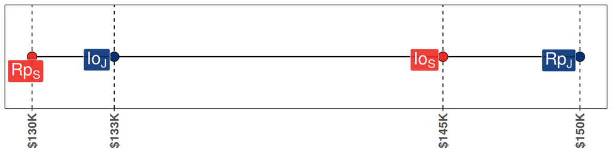

Figure 2: Initial offers

- Buyer: Jackson ($J$) and Seller: Sofia ($S$)
  - Target point $J$, $Tp_J$: 135K USD
  - Target point $S$, $Tp_S$: 140K USD

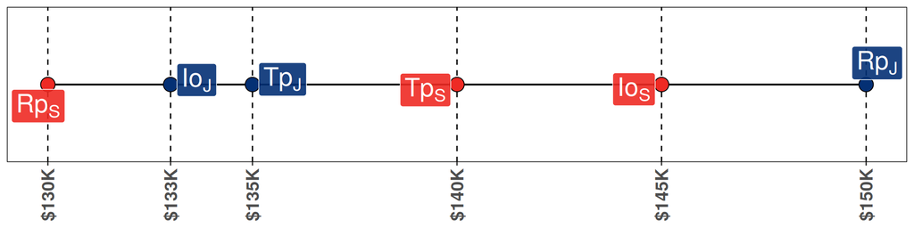

Figure 3: Target points

- Buyer: Jackson ($J$) and Seller: Sofia ($S$)
  - BATNA $J$, $BATNA_J$: 142K USD
  - BATNA $S$, $BATNA_S$: 134K USD

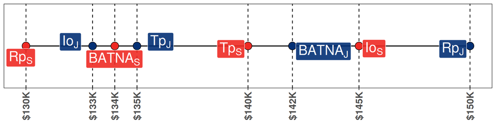

Figure 4: Best alternatives to a negotiated agreement

- Buyer: Jackson ($J$) and Seller: Sofia ($S$)
  - Bargaining range[^2]: $[\text{\$130K},\text{\$150K}]$
    - Is the result of $[\text{\$130K}, \infty) \cap [0, \text{\$150K}]$
    - If the bargaining range is $\neq \emptyset$, $Rp_S \leq BATNA_J$ and $BATNA_S \leq Rp_J$ then an aggrement between $J$ and $S$ is possible

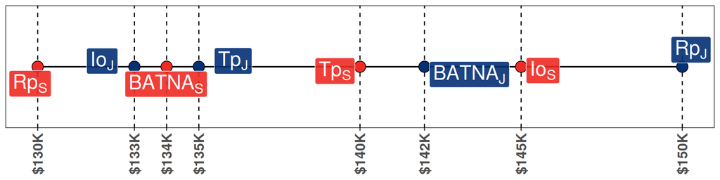

Figure 5: Bargaining range

- Buyer: Jackson ($J$) and Seller: Sofia ($S$)
  - In this example the settlement point $\in [Tp_J, Tp_S] = [\text{\$135K}, \text{\$140K}]$

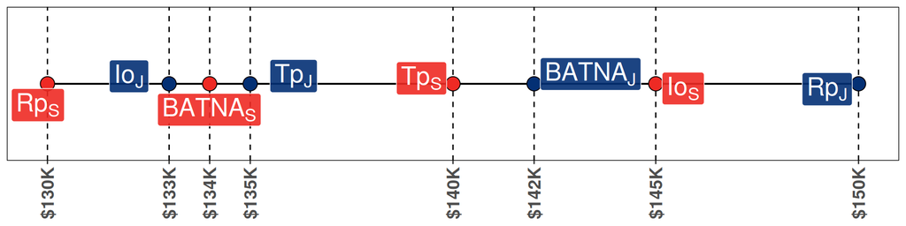

Figure 6: Possible values for a settlement point

- In the case of a distributive negotiation, it is most likely that the settlement point does not correspond to the target points of the participants in the negotiation.
- In the example of $J$ and $S$ it was implicitly assumed that the negotiation element was the price. This element is known as a **bargaining mix**[^3] where it does not necessarily have to be a single element.
  - For example $J$ and $S$ also can include in the bargaining mix the final date of the sale, whether or not renovations are included or if other items such as furniture and household appliances are added.

# Strategies and tactics

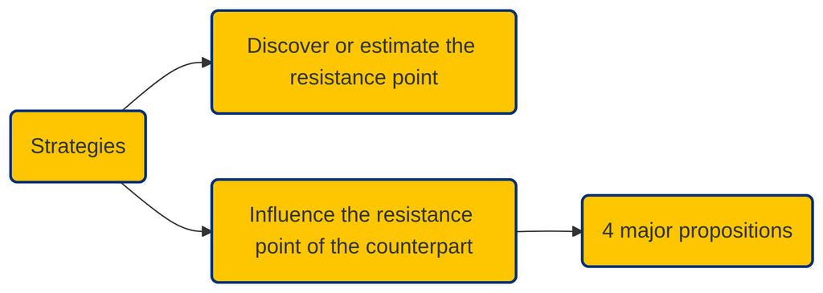

Figure 7: Strategies distributive bargaining (Lewicki et al., 2024, pp. 39–41)

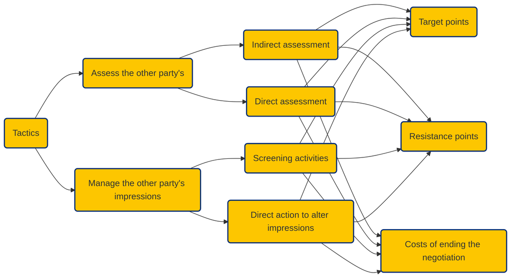

Figure 8: Tactics distributive bargaining (Lewicki et al., 2024, pp. 42–48)[^4]

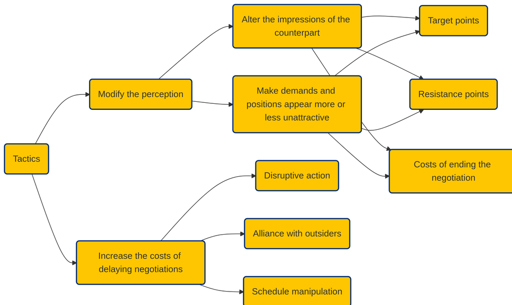

Figure 9: Tactics distributive bargaining (Lewicki et al., 2024, pp. 42–48)

# Aspects about taking positions during a negotiation

- In (Lewicki et al., 2024, Chapter 2, p. 48-55) the recommended positions to be taken with regard to the following elements are pointed out:
  - **Opening offers**
    - Who should make the first offer?
    - What should be the initial offer?
    - Should the offer be perceived as low, moderate or high by the other party?
    - Should the initial offer be near or far from our own resistance point?
  - **Opening stance**
    - Should a moderate or aggressive stance be taken?
  - **Initial concessions**
    - How wide should the initial concession be?
  - **Final offer**
    - How to communicate that a particular offer is a final offer?

# Commitments

- **Commitment** means taking a stance in a negotiation and making a explicit or implicit promise about future actions.
  - A commitment is a way to create a bargaining position by specifying a future action if a position is not reached.
  - A commitment aims to clarify the negotiator’s planned actions and eliminate any uncertainty about their intentions.
    - However, they may also fix a negotiator to a particular position (Lewicki et al., 2024, Chapter 2, p. 56)
    - That is why when making commitments, one should also make contingency plans for a graceful exit if needed
    - Also it is important to point out that good, sound and deliberate commitments take time to establish so it is important to don’t commit prematurely (Lewicki et al., 2024, Chapter 2, p. 56)

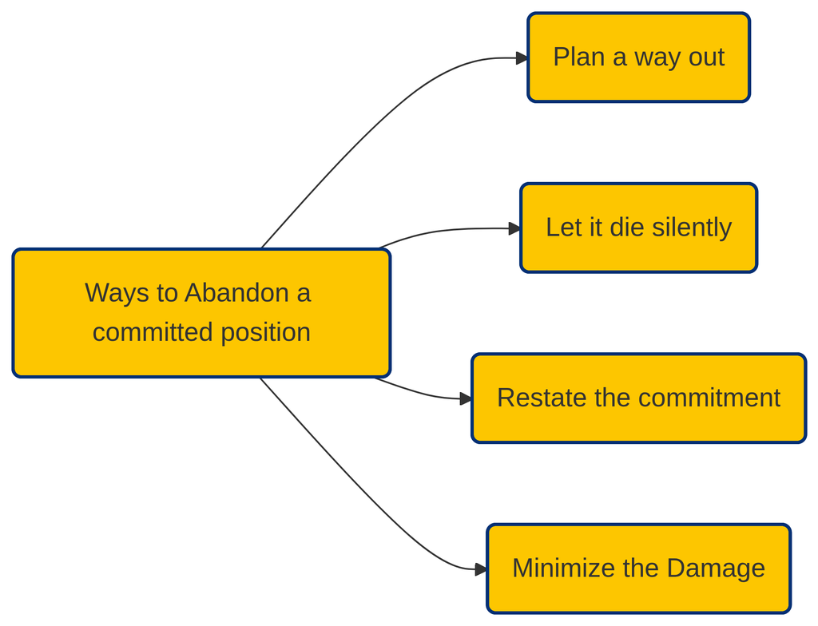

Figure 10: Ways to abandon a committed position (Lewicki et al., 2024, pp. 58–59)

# Closing a deal

- The negotiations seek to reach an agreement if possible[^5]. In order to achieve that goal with a greater probability, the following practices are recommended based on what is pointed out in (Lewicki et al., 2024, Chapter 2, pp. 59-60):
  - Offer similar options to the other parties to make the negotiation more flexible.
  - Assume a closing technique or stance.
  - Split the difference when a **mutual adjustment** process has been carried out.
  - Use **exploding offers** that refers to setting a deadline where a specific proposal is in force for a limited time.
  - Use **sweeteners** that refers to granting special concessions before closing.

# How to face hardball tactics?

- Sometimes in negotiations people use **hardball tactics**. In general in (Lewicki et al., 2024, Chapter 2, p 61) the authors recommend not to use them as they cause damage in the negotiation process. However, it is important to know them and know how to deal with them.
- In (Lewicki et al., 2024, Chapter 2, pp. 61-62) 4 possible strategies to face these tactics are pointed out:
  - Discuss them
  - Ignore them
  - Respond in kind
  - Co-opt the other party

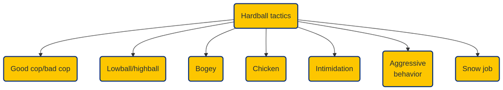

Figure 11: Typical hardball tactics (Lewicki et al., 2024, p. 63)

# Acknowledgments

- To my family that supports me
- To the taxpayers of Colombia and the [**UMNG students**](https://www.umng.edu.co/estudiante) who pay my salary
- To the [**Business Science**](https://www.business-science.io/) and [**R4DS Online Learning**](https://www.rfordatasci.com/) communities where I learn [**R**](https://www.r-project.org/about.html) and [**$\pi$-thon**](https://www.python.org/about/)
- To the [**R Core Team**](https://www.r-project.org/contributors.html), the creators of [**RStudio IDE**](https://posit.co/download/rstudio-desktop/), [**Positron**](https://positron.posit.co/), [**Quarto**](https://quarto.org/) and the authors and maintainers of the packages [**tidyverse**](https://CRAN.R-project.org/package=tidyverse), [**ggrepel**](https://CRAN.R-project.org/package=ggrepel), [**latex2exp**](https://CRAN.R-project.org/package=latex2exp), [**scales**](https://CRAN.R-project.org/package=scales) and [**tinytex**](https://CRAN.R-project.org/package=tinytex) for allowing me to access these tools without paying for a license

# References

Lewicki, R. J., Barry, B., & Saunders, D. M. (2024). *Negociación* (9th ed.). McGraw-Hill Education. https://www-ebooks7-24-com.ezproxy.umng.edu.co/?il=40562

Muthoo, A. (1999). *Bargaining theory with applications*. Cambridge University Press.

## Footnotes

[^1]: Both $J$ and $S$ have a common interest in cooperating but conflicting interests on how exactly to cooperate. For that reason a negotiation situation arises (Muthoo, 1999)
[^2]: Also known as settlement range or zone of potential agreement
[^3]: It is define as the set of issues that will be negotiated
[^4]: In negotiation contexts as it is pointed out in (Lewicki et al., 2024), **screening activities** are tactics used to avoid disclosing sensitive information.
[^5]: Remember that negotiation as a form of decision making is not the only method that exists!